# Key 05 Linear Models

## problem 2: categorical data

2.1

Use ggplot to make a scatter plot of the `blength` observations separated by year.

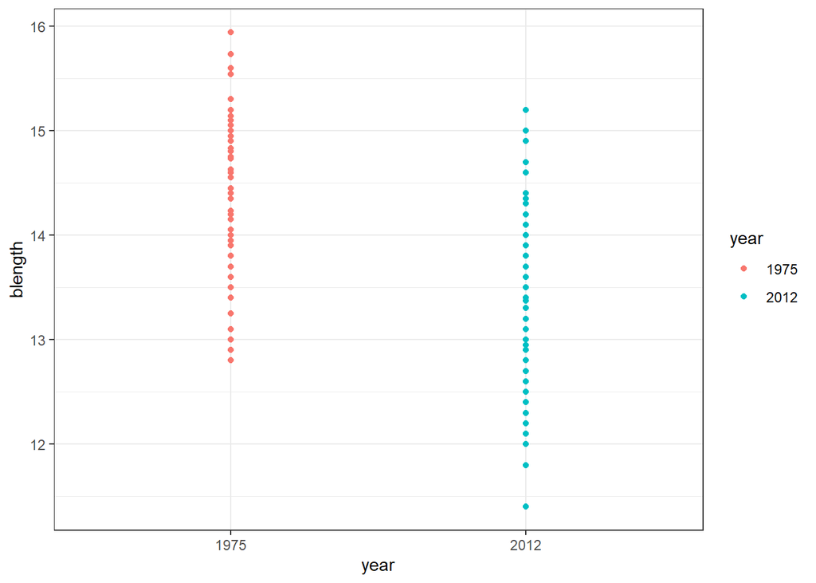

```r
ggplot(scandens,
       aes(x = year,
           y = blength,
           color = year)) +
  geom_point() +
  theme_bw()
```

2.2 Make the same plot as in 2.1 above but “jitter” the points. Make sure to set `width = 0.1` and `height = 0`

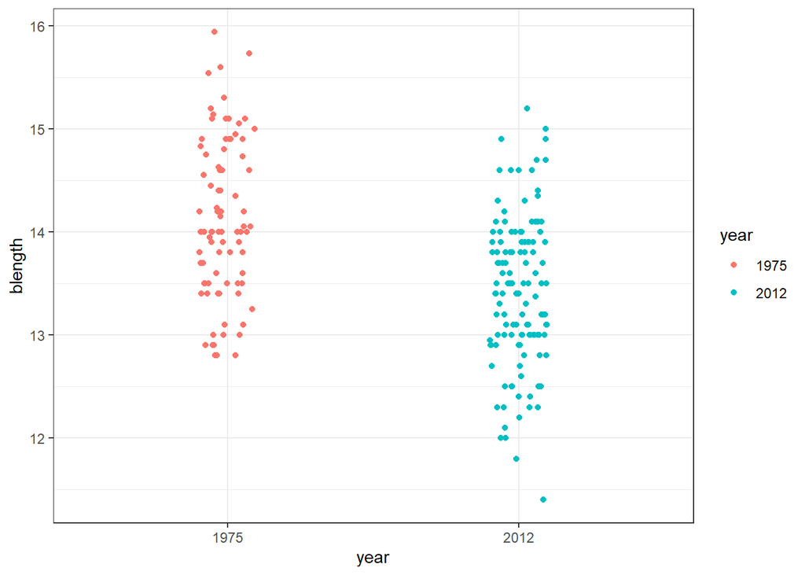

```r
ggplot(scandens,
       aes(x = year,
           y = blength,
           color = year)) +
  geom_point(position = position_jitter(width = 0.1, height = 0)) +
  theme_bw()
```

2.3  
Use `lm()` to fit a model which includes `year` as a predictor variable. Save this model output in an object called `flm1`, and use `display()` to print out the results in your console.

```r
flm1 <- lm(blength ~ year, data = scandens)
display(flm1)
```

```
lm(formula = blength ~ year, data = scandens)
            coef.est coef.se
(Intercept) 14.12     0.08
year2012    -0.70     0.10
---
n = 214, k = 2
residual sd = 0.73, R-Squared = 0.18
```

## GRADED

2.4 Based on the information from 2.3 above, enter a comment in your data which shows the estimated mean beak length for the *scandens* species in *1975*.

```r
# mean 1975 = Intercept = 14.12
```

2.5 Based on the information from 2.3 above, enter a simple arithmetic equation which estimates the the mean beak length for the *scandens* species in 2012?

```r
# mean 2012
14.12 - 0.70
```

```
[1] 13.42
```

## GRADED

2.6 Make a scatter plot of the `scandes` data which separates the observations by year, and includes a point for the estimated group means.  
+ In the `stat_summary()` function, set `shape = 18` and `size = 6`.

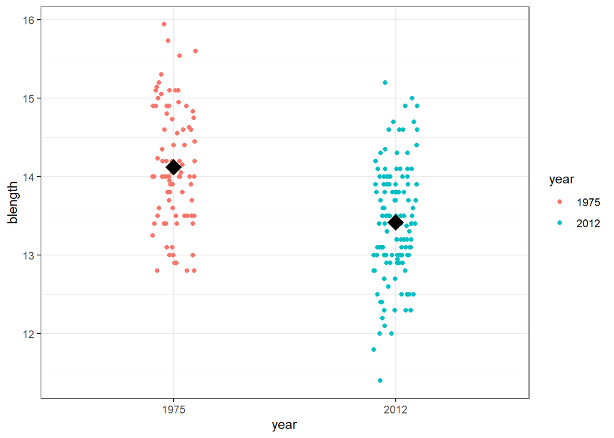

```r
ggplot(scandens,
       aes(x = year,
           y = blength,
           color = year)) +
  geom_point(position = position_jitter(
    width = 0.1,
    height = 0)) +
  stat_summary(fun = mean,
               geom = "point",
               color = "black",
               shape = 18,
               size = 6) +
  theme_bw()
```

## problem 3: confidence interval and coefplot

3.1 Using `confint()` and the `flm1` object, calculate and display a 95% confidence interval for the estimated difference in beak length between 1975 and 2012.

```r
confint(flm1)
```

```
                 2.5 %     97.5 %
(Intercept) 13.9656842 14.2761548
year2012    -0.9014054 -0.4983864
```

3.2  
Use `coefplot()`and the `flm1` object to display a graphical representation of the approximate 95% CI for the estimated difference in beak length between 1975 and 2012.

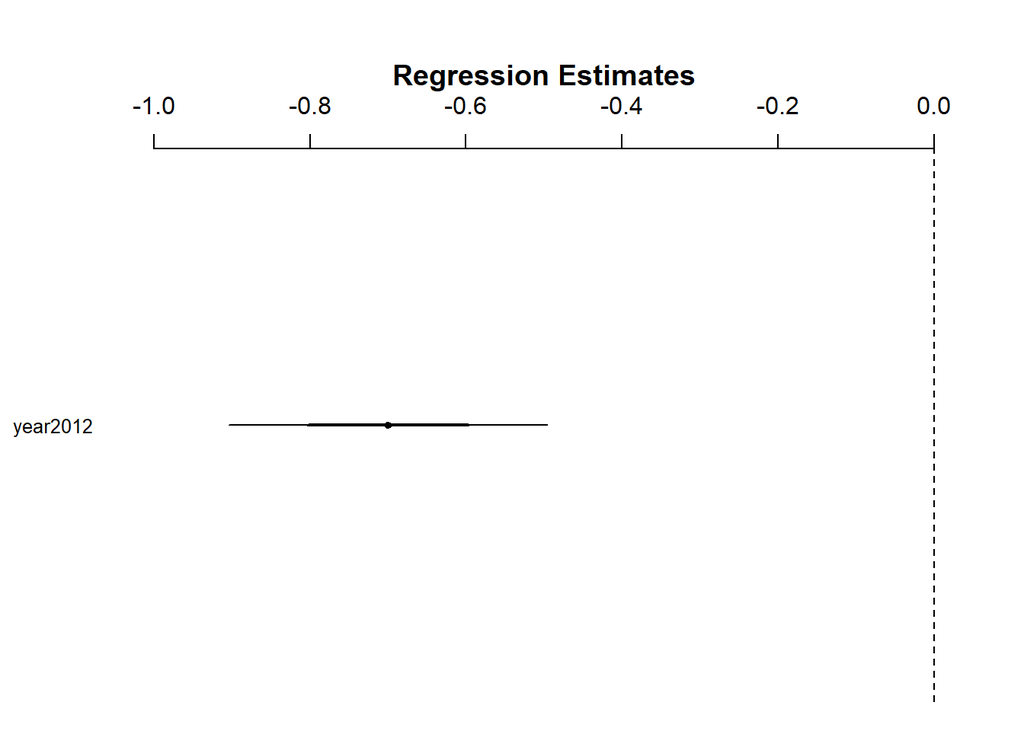

```r
coefplot(flm1, xlim = c(-1, 0))
```

3.3 Add a comment in your script to interpret the results of problem 3.1 and 3.2. Are these interpretations in agreement with each other?

```r
# there is a difference in beak length between 1975 and 2012
# the 95% CI does not include 0, either in the nnumber line or on the plot
```

3.4 Use `confint()` and `flm1` to calculate and display a 99% CI for the estimated difference in beak length between 1975 and 2012.

```r
confint(flm1, level = 0.99)
```

```
                 0.5 %     99.5 %
(Intercept) 13.9162285 14.3256106
year2012    -0.9656034 -0.4341884
```

3.5 Use `coefplot()` to display a graphical representation of the approximate 99% CI for the estimated difference in beak length between 1975 and 2012.

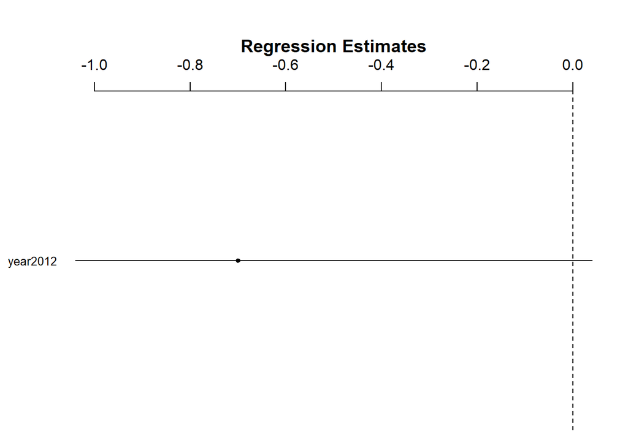

```r
coefplot(flm1, xlim = c(-1, 0), sd = 3)
```

3.6 Use a comment to interpret the results of problem 4.4 and 4.5 above. Are these results in agreement? Why do you think this is?

```r
# Extrapolation of uncertainty, unequal sample size.
```

# problem 4: Assumptions

## GRADED

4.1 Make a Q-Q plot to test the assumption of normally distributed residuals for the `blength` variable in the `scandens` data set.  
+ **Hint** make sure to use `aes(sample = blength)` inside the `ggplot()` function.

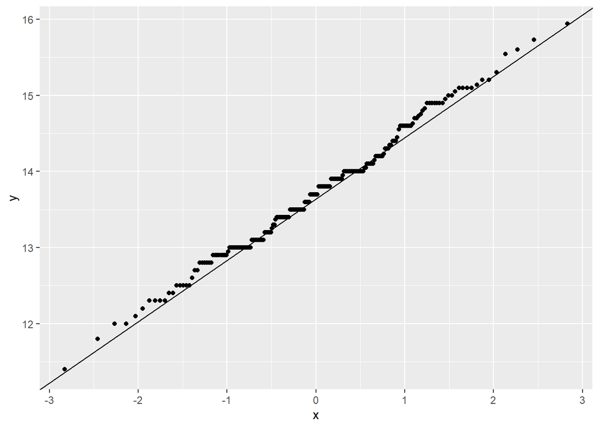

```r
ggplot(scandens, aes(sample = blength)) +
  stat_qq() + # plot qq points
  stat_qq_line() # reference line
```

4.2 Use a comment to interpret the graph you made in problem 4.1 above.

```r
#This indicates that the residuals are normally distributed
```

## GRADED

4.3 Test the assumption of equal variance in the `flm1` model output.  
+ **Hint** make sure to use the model output and not the raw data.  
+ Be sure to include `aes(x = .fitted, y = .resid)` inside the `ggplot()` function.

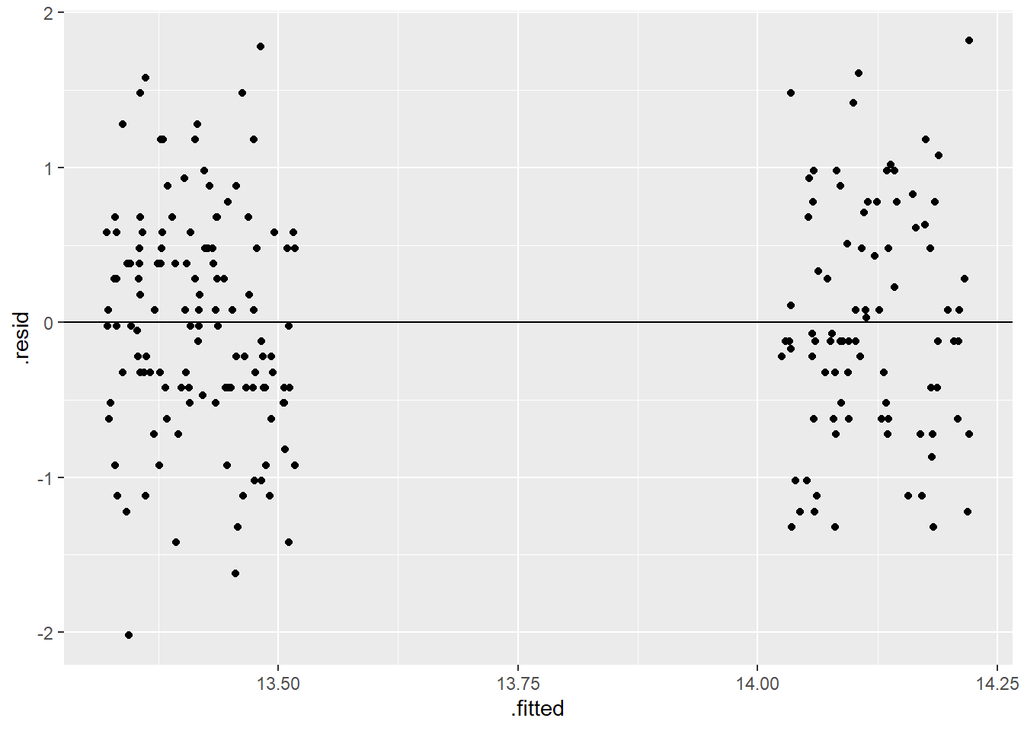

```r
ggplot(flm1,
       aes(x = .fitted, y = .resid)) +
  geom_point(
    position = position_jitter(width = 0.1,
                               height = 0)) +
  geom_hline(yintercept = 0)
```

4.4 Use a comment to interpret the graph you made in problem 4.3 above.

```r
# equal distribution above and below the reference line (0)
# no obvious pattern in points moving across the x-axis
```

# problem 5 relevel the year factor

5.1 Copy the `scandens` data set into a new object called `scandens_factor`. Make the `year` column a factor and order the levels so that 2012 is first. Fit the same linear model as in problem 2.3 but use the new `scandens_factor` data object as the input, and display the results of this new model.

```r
scandens_factor <- scandens

scandens_factor$year <- factor(scandens_factor$year, levels = c("2012", "1975"))

display(lm(blength~year, data = scandens_factor))
```

```
lm(formula = blength ~ year, data = scandens_factor)
            coef.est coef.se
(Intercept) 13.42     0.07
year1975     0.70     0.10
---
n = 214, k = 2
residual sd = 0.73, R-Squared = 0.18
```